# Module 4: Smoothing, Part 2

Xuan Pham

9/10/2019

# Simple Exponential Smoothing (SES)

First, let’s look at the data set for the week. Oil production in Saudi Arabia

```r
library(forecast)
library(fpp2)
```

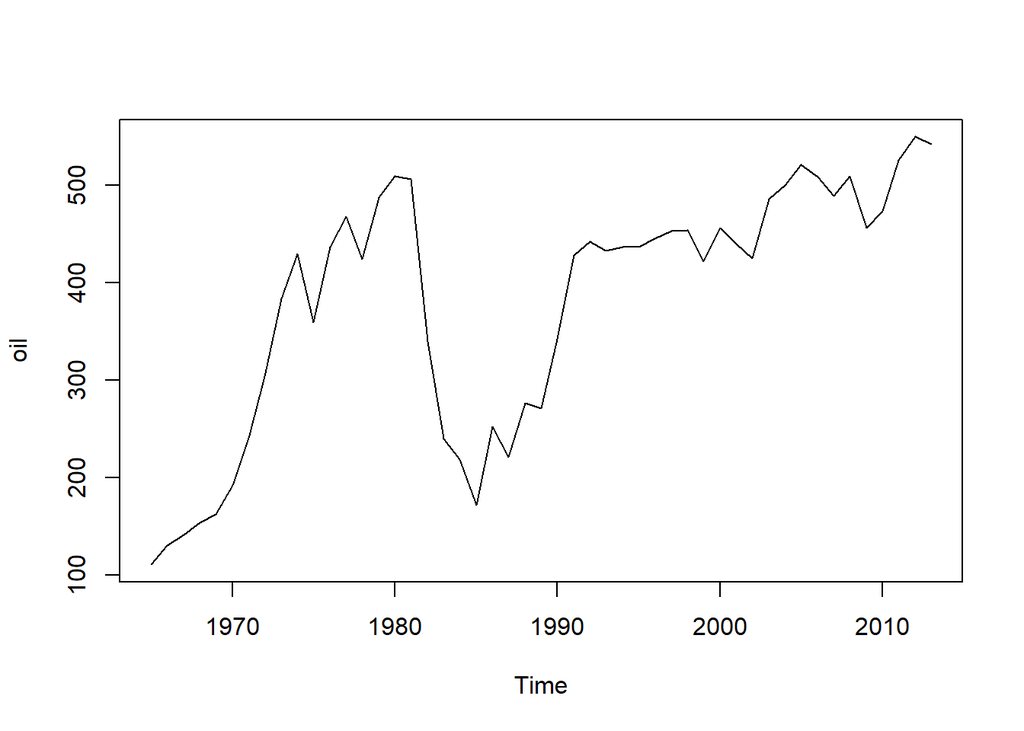

```r
plot(oil) #entire series
```

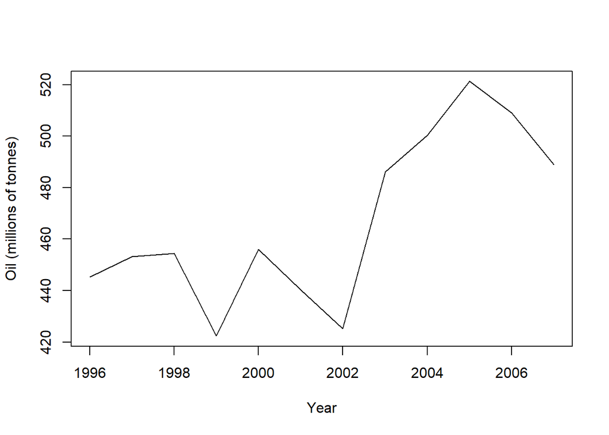

```r
oildata <- window(oil, start = 1996, end = 2007) #subset of series
plot(oildata, ylab = "Oil (millions of tonnes)", xlab = "Year")
```

We know that we can deploy these simple forecasting methods:  
* naive  
* moving average

What if we do not give equal weights to all observations? What if weights are assigned based on whether we think the more recent history or distant past is more important?

```r
fit1 <- ses(oildata, alpha = 0.2, initial = "simple", h = 3)
fit2 <- ses(oildata, alpha = 0.6, initial = "simple", h = 3)
fit3 <- ses(oildata, h = 3) #note no value for alpha and no initial value.  The algorithm will calculate alpha as part of the optimization.

#what kind of objects are these?
class(fit3)
```

```
## [1] "forecast"
```

```r
#what is in them
summary(fit3)
```

```
##
## Forecast method: Simple exponential smoothing
##
## Model Information:
## Simple exponential smoothing
##
## Call:
##  ses(y = oildata, h = 3)
##
##   Smoothing parameters:
##     alpha = 0.7956
##
##   Initial states:
##     l = 446.7948
##
##   sigma:  27.1495
##
##      AIC     AICc      BIC
## 112.8636 115.8636 114.3183
##
## Error measures:
##                   ME     RMSE      MAE       MPE     MAPE     MASE
## Training set 4.86894 24.78395 19.65328 0.8653916 4.179747 0.923691
##                    ACF1
## Training set -0.0431624
##
## Forecasts:
##      Point Forecast    Lo 80    Hi 80    Lo 95    Hi 95
## 2008       493.2803 458.4869 528.0737 440.0684 546.4923
## 2009       493.2803 448.8182 537.7424 425.2814 561.2792
## 2010       493.2803 440.9050 545.6557 413.1791 573.3815
```

```r
summary(fit2)
```

```
##
## Forecast method: Simple exponential smoothing
##
## Model Information:
## Simple exponential smoothing
##
## Call:
##  ses(y = oildata, h = 3, initial = "simple", alpha = 0.6)
##
##   Smoothing parameters:
##     alpha = 0.6
##
##   Initial states:
##     l = 445.3641
##
##   sigma:  25.2026
## Error measures:
##                    ME    RMSE      MAE      MPE     MAPE      MASE
## Training set 7.121036 25.2026 19.57078 1.311303 4.138815 0.9198136
##                    ACF1
## Training set 0.09497862
##
## Forecasts:
##      Point Forecast    Lo 80    Hi 80    Lo 95    Hi 95
## 2008       496.6356 464.3371 528.9340 447.2394 546.0317
## 2009       496.6356 458.9694 534.3017 439.0302 554.2409
## 2010       496.6356 454.2766 538.9945 431.8531 561.4180
```

Now let’s look at some plots.

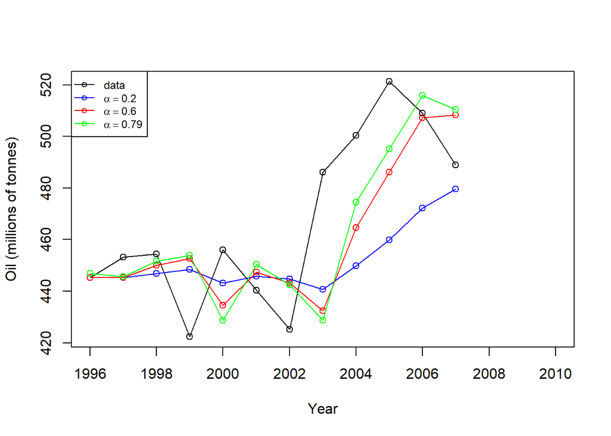

```r
plot(fit1, PI=FALSE, ylab="Oil (millions of tonnes)",
     xlab="Year", main="", fcol="white", type="o")
lines(fitted(fit1), col="blue", type="o")
lines(fitted(fit2), col="red", type="o")
lines(fitted(fit3), col="green", type="o")

legend("topleft",lty=1, col=c(1,"blue","red","green"), cex = 0.75,
       c("data", expression(alpha == 0.2), expression(alpha == 0.6),
         expression(alpha == 0.79)),pch=1)
```

What if we want to use our SES methods to forecast three years ahead? 2008-2010

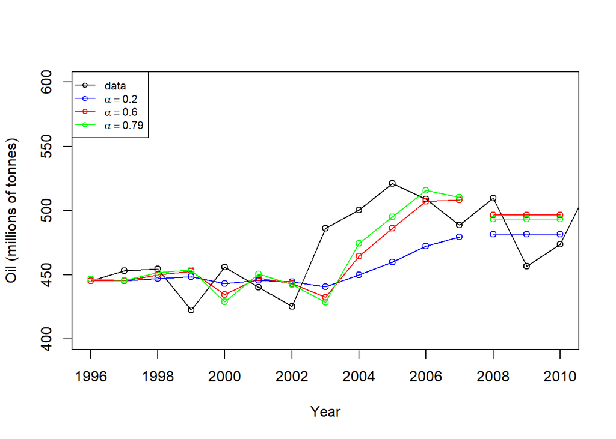

```r
fit1 <- ses(oildata, alpha = 0.2, initial = "simple", h = 3)
fit2 <- ses(oildata, alpha = 0.6, initial = "simple", h = 3)
fit3 <- ses(oildata, h = 3)

plot(fit1, PI=FALSE, ylim = c(400, 600), ylab="Oil (millions of tonnes)",
xlab="Year", main="", fcol="white", type="o")
#this just plots the data through 2007 because that's what we ran the model over
#we have more data but have to plot it seperately if we want to compare the forecast with the actual
# add these lines for putting the actual data past 2007
test.oil <- window(oil, start = 2007)
lines(test.oil, col = "black", type = "o")
lines(fitted(fit1), col="blue", type="o")
lines(fitted(fit2), col="red", type="o")
lines(fitted(fit3), col="green", type="o")
lines(fit1$mean, col="blue", type="o")
lines(fit2$mean, col="red", type="o")
lines(fit3$mean, col="green", type="o")
legend("topleft",lty=1, cex =0.75, col=c(1,"blue","red","green"),
c("data", expression(alpha == 0.2), expression(alpha == 0.6),
expression(alpha == 0.79)),pch=1)
```

# Holt’s Linear Trend

The problem with SES is that it does not forecast anything else but a flat line. What if we expect forecasts to have a trend?

```r
fith <- holt(oildata, alpha=0.8, beta=0.2, initial="simple", h=3)
class(fith)
```

```
## [1] "forecast"
```

```r
summary(fith)
```

```
##
## Forecast method: Holt's method
##
## Model Information:
## Holt's method
##
## Call:
##  holt(y = oildata, h = 3, initial = "simple", alpha = 0.8, beta = 0.2)
##
##   Smoothing parameters:
##     alpha = 0.8
##     beta  = 0.2
##
##   Initial states:
##     l = 445.3641
##     b = 7.8309
##
##   sigma:  26.6089
## Error measures:
##                     ME     RMSE     MAE        MPE     MAPE     MASE
## Training set -2.062825 26.60893 21.6139 -0.5912386 4.622665 1.015839
##                     ACF1
## Training set -0.02963702
##
## Forecasts:
##      Point Forecast    Lo 80    Hi 80    Lo 95    Hi 95
## 2008       499.5248 465.4241 533.6255 447.3722 551.6773
## 2009       503.3951 455.1694 551.6208 429.6402 577.1499
## 2010       507.2653 444.0179 570.5128 410.5368 603.9939
```

```r
oildata[1]
```

```
## [1] 445.3641
```

Notice that it shows the parameter settings we gave it. We now have a setting for the effect of the trend. What’s the initial value? It’s the first value of the oildata series - because we set the initialization routine = “simple” fith$mean.

Adding these lines to our chart. What is the effect of adding trend?

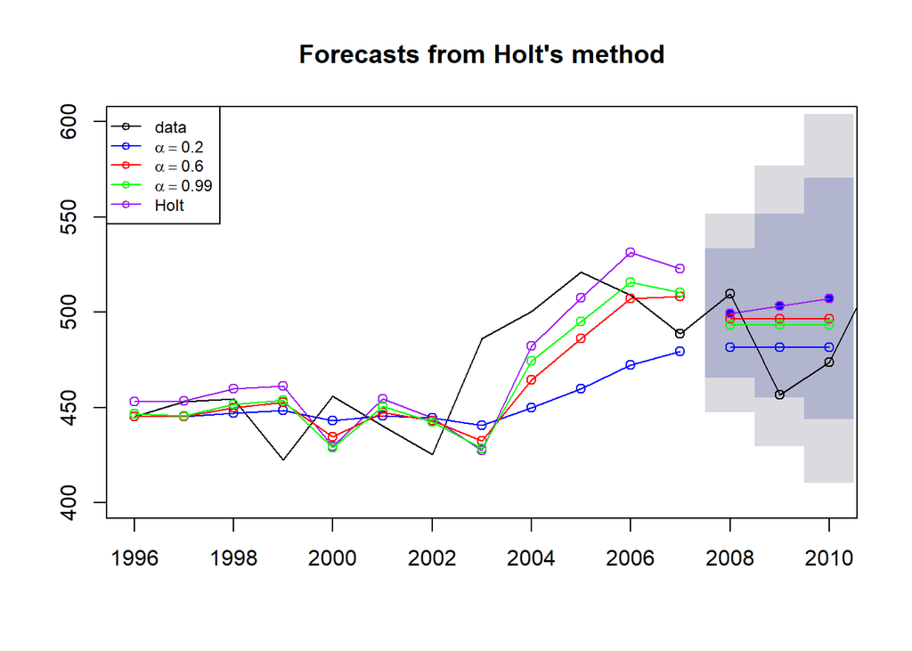

```r
plot(fith, PI=TRUE, ylim = c(400, 600))
lines(fitted(fith), type = "o", col="purple")
lines(fith$mean, col="purple", type="o")
lines(test.oil, col = "black", type = "o")
lines(fitted(fit1), col="blue", type="o")
lines(fitted(fit2), col="red", type="o")
lines(fitted(fit3), col="green", type="o")
lines(fit1$mean, col="blue", type="o")
lines(fit2$mean, col="red", type="o")
lines(fit3$mean, col="green", type="o")
legend("topleft",lty=1, cex = 0.75, col=c(1,"blue","red","green", "purple"),
       c("data", expression(alpha == 0.2), expression(alpha == 0.6),
         expression(alpha == 0.99),"Holt"),pch=1)
```

That was the additive trend Holt’s method - let’s make it muliplicative.

```r
fith2 <- holt(oildata,alpha=0.8,beta=0.2,initial="simple",exponential=TRUE,h=3)
summary(fith2)
```

```
##
## Forecast method: Holt's method with exponential trend
##
## Model Information:
## Holt's method with exponential trend
##
## Call:
##  holt(y = oildata, h = 3, initial = "simple", exponential = TRUE,
##
##  Call:
##      alpha = 0.8, beta = 0.2)
##
##   Smoothing parameters:
##     alpha = 0.8
##     beta  = 0.2
##
##   Initial states:
##     l = 445.3641
##     b = 1.0176
##
##   sigma:  0.0588
## Error measures:
##                     ME     RMSE     MAE        MPE     MAPE     MASE
## Training set -2.704003 26.81176 21.7455 -0.7209538 4.651922 1.022024
##                     ACF1
## Training set -0.02855242
##
## Forecasts:
##      Point Forecast    Lo 80    Hi 80    Lo 95    Hi 95
## 2008       500.7304 461.9559 538.4494 442.3588 558.3945
## 2009       505.5078 451.5184 560.4305 426.9695 590.8898
## 2010       510.3308 440.6160 584.1230 408.7553 624.9579
```

We specified alpha and beta and told it to start with the initial value and the initial trend.

Now add that line to the chart:

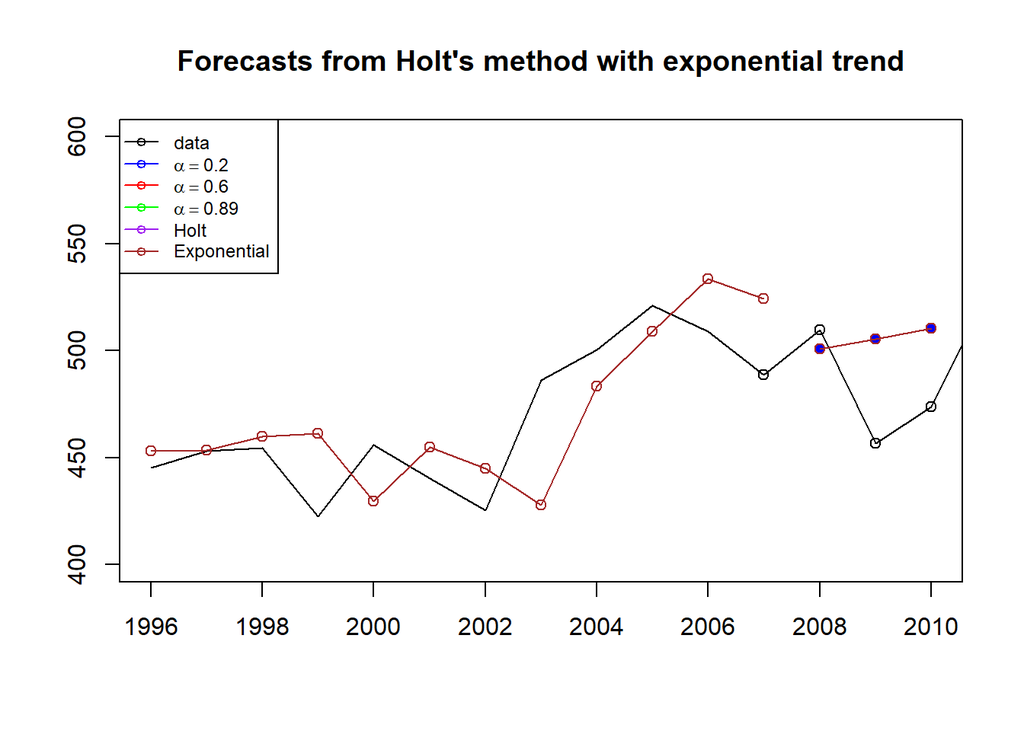

```r
plot(fith2, PI=FALSE, ylim = c(400, 600))
lines(test.oil, col = "black", type = "o")
lines(fitted(fith2), col="brown", type = "o")
lines(fith2$mean, col="brown", type="o")
legend("topleft", cex =0.75, lty=1, col=c(1,"blue","red","green", "purple", "brown"),
       c("data", expression(alpha == 0.2), expression(alpha == 0.6),
         expression(alpha == 0.89),"Holt","Exponential"),pch=1)
```

Let’s look closer at the components of each forecast output.

```r
fith2$model
```

```
## Holt's method with exponential trend
##
## Call:
##  holt(y = oildata, h = 3, initial = "simple", exponential = TRUE,
##
##  Call:
##      alpha = 0.8, beta = 0.2)
##
##   Smoothing parameters:
##     alpha = 0.8
##     beta  = 0.2
##
##   Initial states:
##     l = 445.3641
##     b = 1.0176
##
##   sigma:  0.0588
```

```r
fith2$x
```

```
## Time Series:
## Start = 1996
## End = 2007
## Frequency = 1
##  [1] 445.3641 453.1950 454.4096 422.3789 456.0371 440.3866 425.1944
##  [8] 486.2052 500.4291 521.2759 508.9476 488.8889
```

```r
fith2$fitted
```

```
## Time Series:
## Start = 1996
## End = 2007
## Frequency = 1
##  [1] 453.1950 453.5314 459.9023 461.2979 429.7498 454.7545 444.9082
##  [8] 427.6789 483.2416 509.0280 533.4373 524.4355
```

```r
fith2$mean
```

```
## Time Series:
## Start = 2008
## End = 2010
## Frequency = 1
## [1] 500.7304 505.5078 510.3308
```

What about Holt’s trend with a damped factor?

```r
fith3 <- holt(oildata,alpha=0.8,beta=0.2,initial="simple",exponential=TRUE,
              damped=TRUE, phi=NULL, h=3) #setting phi=NULL allows R to automatically come up with the best damped factor.
summary(fith3)
```

[output not shown]

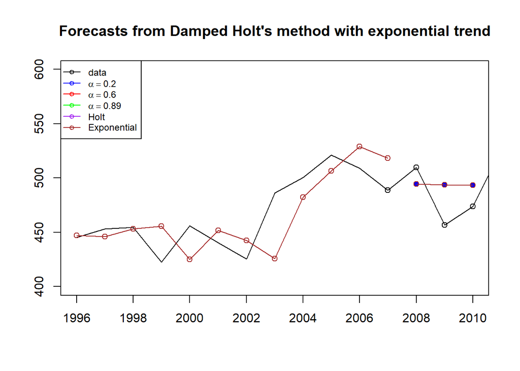

```r
plot(fith3, PI=FALSE, ylim = c(400, 600))
lines(test.oil, col = "black", type = "o")
lines(fitted(fith3), col="brown", type = "o")
lines(fith3$mean, col="brown", type="o")
legend("topleft", cex =0.75, lty=1, col=c(1,"blue","red","green", "purple", "brown"),
       c("data", expression(alpha == 0.2), expression(alpha == 0.6),
         expression(alpha == 0.89),"Holt","Exponential"),pch=1)
```

#Holt-Winters’ Method

But what if there is seasonality in the time series?

First, we need to find a different time series (with seasonality) to examine. Here’s a time series of tourists coming to Australia.

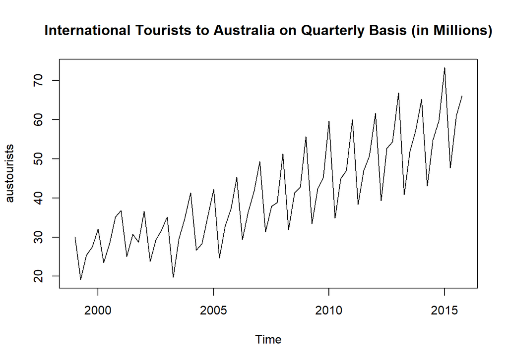

```r
#?austourists
plot(austourists, main = "International Tourists to Australia on Quarterly Basis (in Millions)")
```

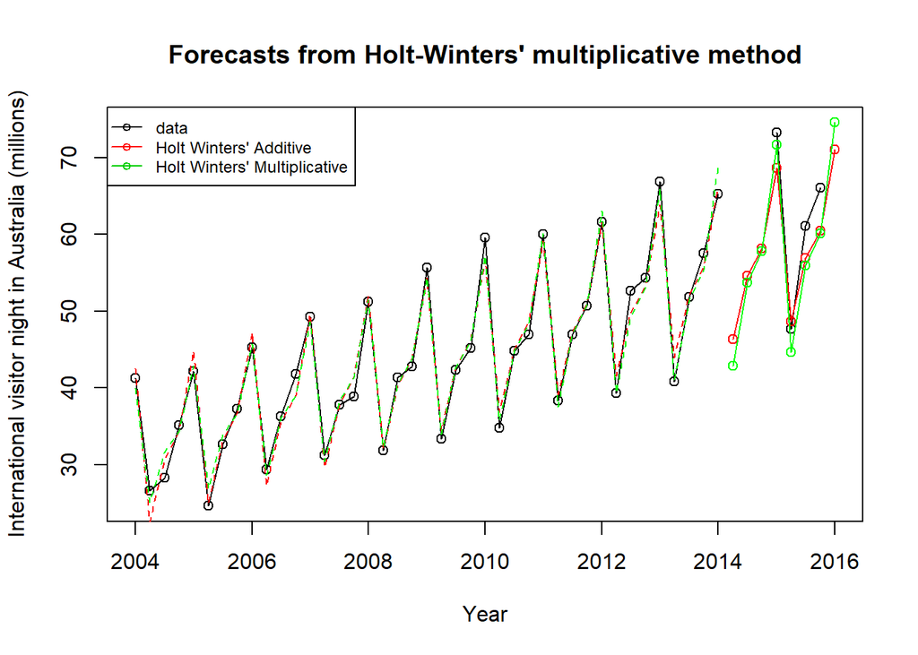

```r
aust <- window(austourists,start=2004, end=2014) #let's make the series a bit shorter for manageability purpose.
fit1hw <- hw(aust,seasonal="additive")
fit2hw <- hw(aust,seasonal="multiplicative")

#Can you take a look at Holt Winters method with damped factor for trend?

test.aust <- window(austourists, start=2015)
plot(fit2hw,ylab="International visitor night in Australia (millions)",
     PI=FALSE, type="o", fcol="white", xlab="Year")
lines(test.aust, col = "black", type = "o")
lines(fitted(fit1hw), col="red", lty=2)
lines(fitted(fit2hw), col="green", lty=2)
lines(fit1hw$mean, type="o", col="red")
lines(fit2hw$mean, type="o", col="green")
legend("topleft",lty=1, cex = 0.75, pch=1, col=1:3,
  c("data","Holt Winters' Additive","Holt Winters' Multiplicative"))
```

We can pull the different pieces out of the forecast object and compare them across specifications. What’s the difference between additive seasonal and multiplicative seasonal?

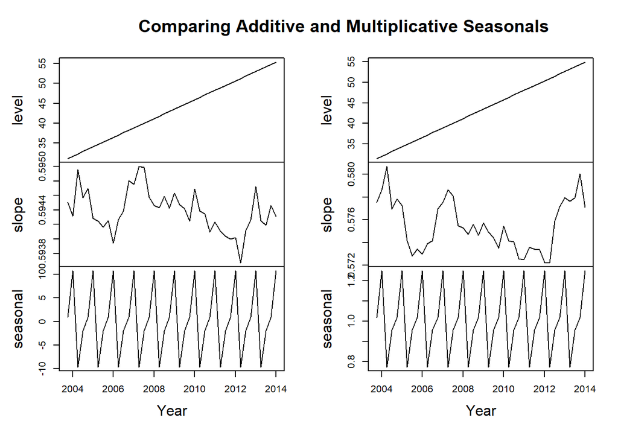

```r
states <- cbind(fit1hw$model$states[,1:3],fit2hw$model$states[,1:3])
colnames(states) <- c("level","slope","seasonal","level","slope","seasonal")
plot(states, xlab="Year", main = "Comparing Additive and Multiplicative Seasonals")
```

# ETS (Error-Trend-Seasonal) Statistical Models

Let’s revisit the oil data - we originally used the SES method on it which is equivalent to ETS(A,N,N)

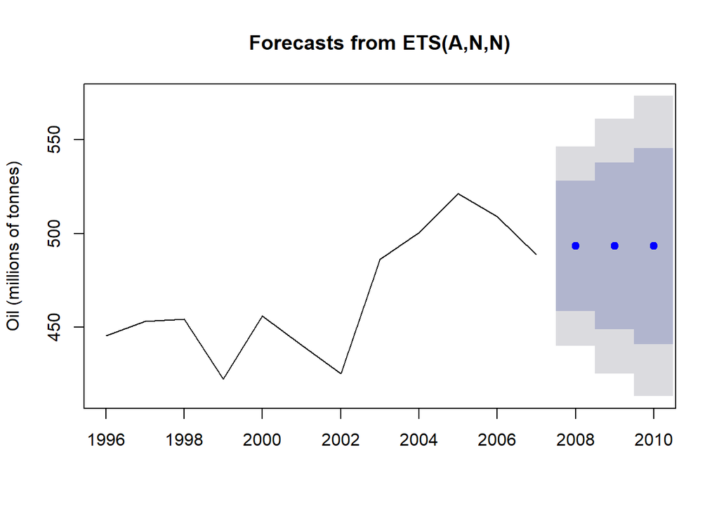

```r
oildata <- window(oil, start = 1996, end = 2007)
fita <- ets(oildata, model = "ANN")
plot(forecast(fita, h=3), ylab="Oil (millions of tonnes)")
```

```r
summary(fita)
```

```
## ETS(A,N,N)
##
## Call:
##  ets(y = oildata, model = "ANN")
##
##   Smoothing parameters:
##     alpha = 0.7958
##
##   Initial states:
##     l = 446.7849
##
##   sigma:  27.1495
##
##      AIC     AICc      BIC
## 112.8636 115.8636 114.3183
##
## Training set error measures:
##                    ME     RMSE      MAE       MPE     MAPE     MASE
## Training set 4.868242 24.78395 19.65274 0.8652851 4.179647 0.923666
##                     ACF1
## Training set -0.04331639
```

```r
ls(fita)  #list names of the objects in the specified environment
```

```
##  [1] "aic"        "aicc"       "amse"       "bic"        "call"
##  [6] "components" "fit"        "fitted"     "initstate"  "loglik"
## [11] "m"          "method"     "mse"        "par"        "residuals"
## [16] "series"     "sigma2"     "states"     "x"
```

```r
fita$par
```

```
##       alpha           l
##   0.7958197 446.7849382
```

What if we used the ETS(M,N,N) model?

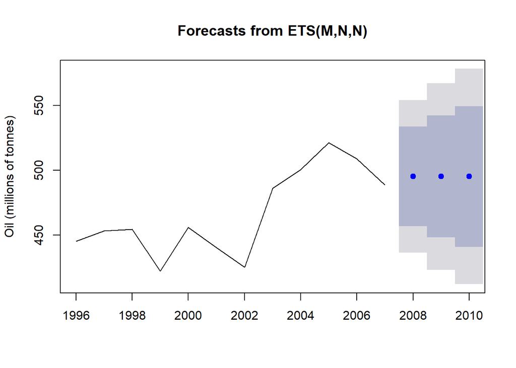

```r
oildata <- window(oil, start = 1996, end = 2007)
fitm <- ets(oildata, model = "MNN")
plot(forecast(fitm, h=3), ylab="Oil (millions of tonnes)")
```

```r
summary(fitm)
```

```
## ETS(M,N,N)
##
## Call:
##  ets(y = oildata, model = "MNN")
##
##   Smoothing parameters:
##     alpha = 0.7022
##
##   Initial states:
##     l = 445.538
##
##   sigma:  0.0606
##
##      AIC     AICc      BIC
## 113.5169 116.5169 114.9716
##
## Training set error measures:
##                    ME     RMSE     MAE      MPE     MAPE      MASE
## Training set 5.889318 24.87807 19.5004 1.068927 4.137105 0.9165061
##                    ACF1
## Training set 0.02210889
```

```r
ls(fitm)  #list names of the objects in the specified environment
```

```
##  [1] "aic"        "aicc"       "amse"       "bic"        "call"
##  [6] "components" "fit"        "fitted"     "initstate"  "loglik"
## [11] "m"          "method"     "mse"        "par"        "residuals"
## [16] "series"     "sigma2"     "states"     "x"
```

```r
fitm$par
```

```
##       alpha           l
##   0.7021876 445.5380329
```

But are either of these the right model for these data? What if we let the ETS code decide?

```r
oildata <- window(oil, start = 1996, end = 2007)
fit <- ets(oildata)
summary(fit)
```

```
## ETS(A,N,N)
##
## Call:
##  ets(y = oildata)
##
##   Smoothing parameters:
##     alpha = 0.7958
##
##   Initial states:
##     l = 446.7849
##
##   sigma:  27.1495
##
##      AIC     AICc      BIC
## 112.8636 115.8636 114.3183
##
## Training set error measures:
##                    ME     RMSE      MAE       MPE     MAPE     MASE
## Training set 4.868242 24.78395 19.65274 0.8652851 4.179647 0.923666
##                     ACF1
## Training set -0.04331639
```

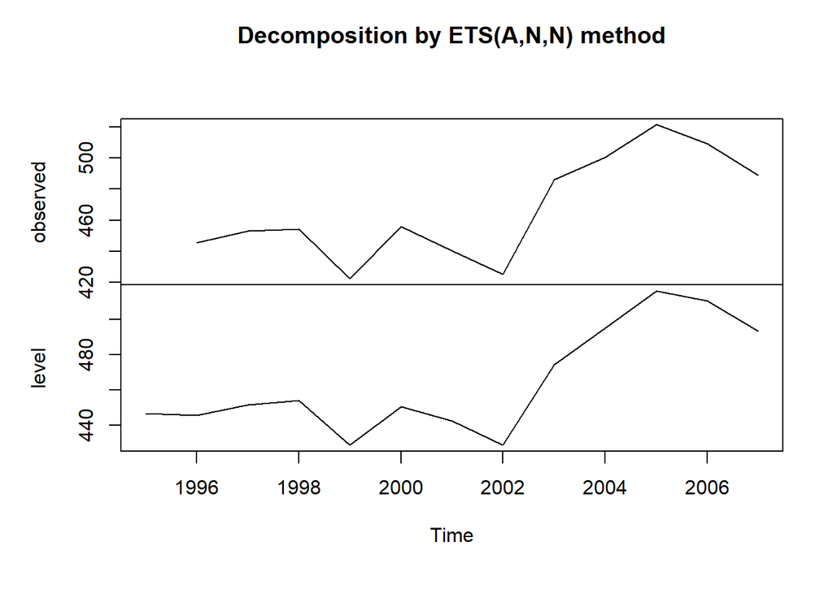

```r
plot(fit)
```

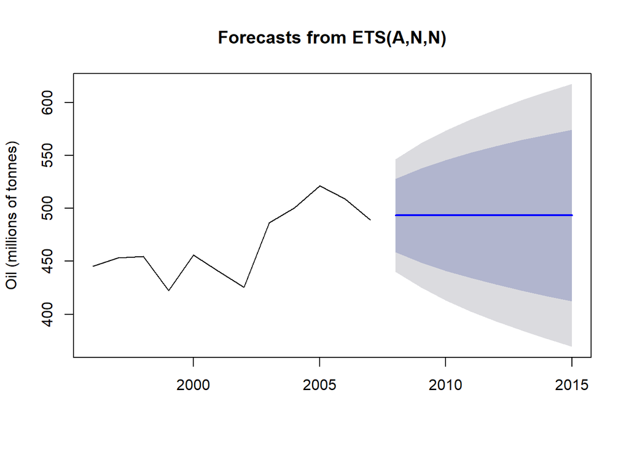

```r
plot(forecast(fit, h = 8), ylab = "Oil (millions of tonnes)")
```

The model chose additive. Compare the AIC for the two we examined.

```r
fita$aic
```

```
## [1] 112.8636
```

```r
fitm$aic
```

```
## [1] 113.5169
```

Yup - the AIC for the additive model is lower so it is the “better” model–but not by much.

How about a more interesting example? Remember the Australian tourism time series?

Very strongly seasonal. Probably not a good candidate for the ETS(A,N,N) model. Let’s see:

```r
fit <- ets(aust)
summary(fit)
```

```
## ETS(M,A,M)
##
## Call:
##  ets(y = aust)
##
##   Smoothing parameters:
##     alpha = 1e-04
##     beta  = 1e-04
##     gamma = 2e-04
##
##   Initial states:
##     l = 31.3602
##     b = 0.5784
##     s = 1.0267 0.9504 0.77 1.2528
##
##   sigma:  0.0396
##
##      AIC     AICc      BIC
## 204.1782 209.9846 219.6003
##
## Training set error measures:
##                       ME     RMSE      MAE       MPE     MAPE      MASE
## Training set -0.04042055 1.460647 1.109073 -0.238826 2.686734 0.4153527
##                     ACF1
## Training set -0.08350248
```

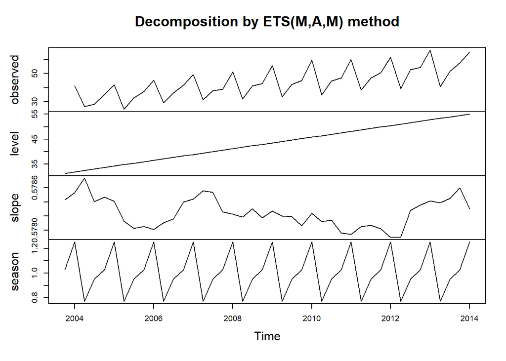

```r
plot(fit)
```

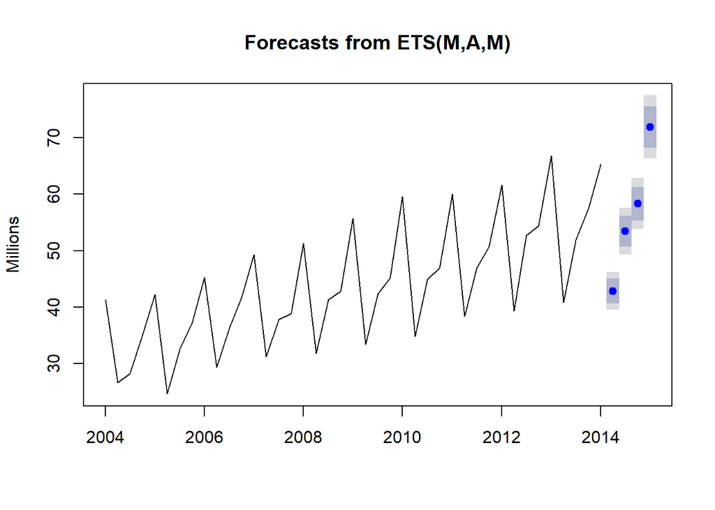

```r
plot(forecast(fit, h = 4), ylab = "Millions")
```

What about our ubiquitous air passengers data?

```r
ap <- window(AirPassengers)
fit <- ets(ap)
summary(fit)
```

```
## ETS(M,Ad,M)
##
## Call:
##  ets(y = ap)
##
##   Smoothing parameters:
##     alpha = 0.7096
##     beta  = 0.0204
##     gamma = 1e-04
##     phi   = 0.98
##
##   Initial states:
##     l = 120.9939
##     b = 1.7705
##     s = 0.8944 0.7993 0.9217 1.0592 1.2203 1.2318
##            1.1105 0.9786 0.9804 1.011 0.8869 0.9059
##
##   sigma:  0.0392
##
##      AIC     AICc      BIC
## 1395.166 1400.638 1448.623
##
## Training set error measures:
##                    ME     RMSE      MAE       MPE     MAPE      MASE
## Training set 1.567359 10.74726 7.791605 0.4357799 2.857917 0.2432573
##                    ACF1
## Training set 0.03945056
```

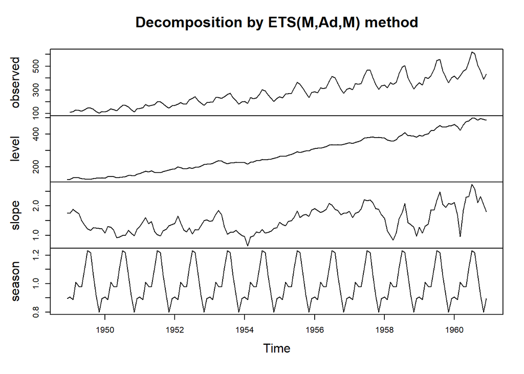

```r
plot(fit)
```

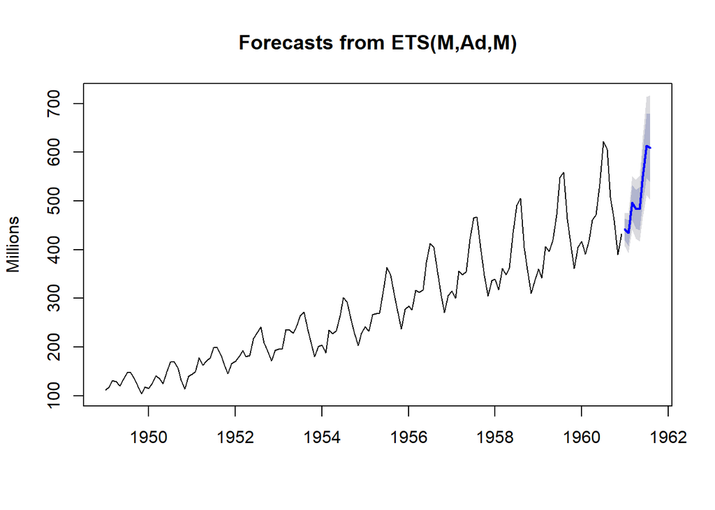

```r
plot(forecast(fit, h = 8), ylab = "Millions")
```